# Rencontres R - Rennes 2018 - `chart` et `flow` tutoriel

Version commentée et augmentée de RRennes2018_presentation.Rmd.

## Installation

Installer la versions en développement sur Github des packages discutés ici est nécessaire au préalable :

```r
#install.packages("devtools")
##install.packages(c("tidyverse", "latticeExtra", "cowplot",
#  "pryr", "ggpubr", "ggplotify", "svMisc", "proto", "tsibble",
#  "Hmisc", "nycflights13"))
#devtools::install_github("SciViews/data")
#devtools::install_github("SciViews/chart")
#devtools::install_github("SciViews/flow")
#
#library(tidyverse)
#library(data)
#library(chart)
#library(flow)
#
#ou plus simplement, lorsque la prichaine version SciViews sera sur CRAN :
#install.packages("Sciviews")
SciViews::R
```

Nous utiliserons le jeu de données `urchin_bio` du package `data`, avec annotation (`label` et `units`) en français. Cela se fait avec la fonction `read()` du package `data` :

```r
urchin <- data::read("urchin_bio", package = "data", lang = "FR")
```

Ce jeu de données contient diverses mesures de biométrie sur deux populations d’oursins : ceux provenant d’élevage (“Culture”) et ceux provenant du milieu naturel (“Pêcherie”).

## Pourquoi utiliser `read()` à la place de `data()` pour charger un package R ?

- Difficultés ches les débutants entre `data(<dataset>)` et `<df> <- read.csv("<filepath>", <args>)` : “patterns” différents.
- dans **data**, pattern similaire:

`<df> <- read("<dataset>", <args>)`

deux cas:

- jeu de données d’un package R:

`<df> <- read("<dataset_name>", package = "<pkg>")`

- fichier:

`<df> <- read("<dataset_file>", <args>)`

- Possibilité d’annoter les variables (attributs `label` et `units`) dans différentes langues. Cette information sera utilisée par `chart()` plus tard.

```r
#View(urchin) # Les labels apparaissent dans RStudio
attributes(urchin$skeleton) # Label et unités enregistrés
```

```
$label
[1] "Masse du squelette"

$units
[1] "g"
```

## Utilisation de `chart`

Masse squelettique des oursins en fonction de la masse totale?

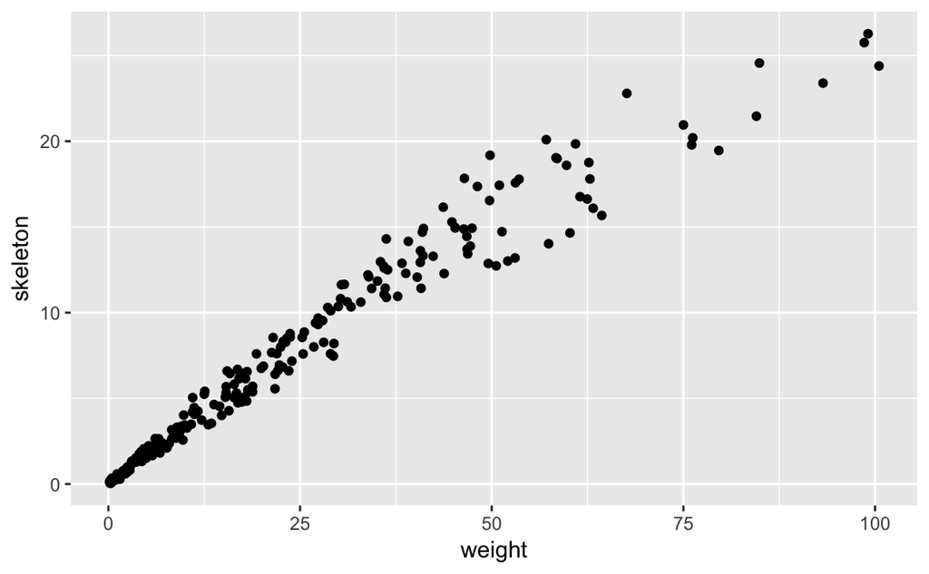

```r
ggplot(data = urchin, aes(weight, skeleton)) +
  geom_point()
```

Patterns: les premiers graphes que les étudiants voient s’impriment dans leur esprit comme les exemples à suivre. `ggplot2` produit des graphes très proches d’un idéal, mais:

- thème par défaut particulier (fond gris)
- mauvais libellé des axes et unités manquantes

=> Utiliser un autre thème par défaut => Prendre en compte le label et les unités enregistrés dans le jeu de données

=> chart(). Remplacement mininal de la syntaxe `ggplot()`

**Règle `chart()` #1:** `chart()`peut remplacer `ggplot()` sans changer le reste.

```r
chart(data = urchin, aes(weight, skeleton)) +
  geom_point()
```

[output not shown]

### Interface formule

Effectuons une régression linéaire :

```r
(lmod <- lm(data = urchin, skeleton ~ weight))
```

```
Call:
lm(formula = skeleton ~ weight, data = urchin)

Coefficients:
(Intercept)       weight
     0.6882       0.2828
```

Patterns différents avec position des variables x et y inversées:

`aes(<x>, <y>)` *versus* `<y> ~ <x>` => source de confusion et d’erreur!

**Règle `chart()` #2 :** `f_aes()` à la place de `aes()`, permettant de spécifier les “aesthetics” via des formules.

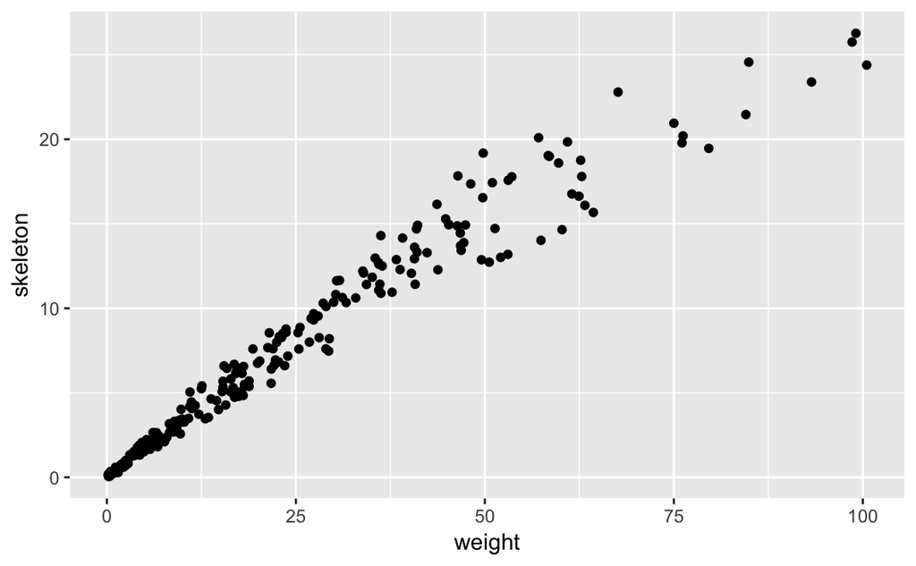

```r
ggplot(data = urchin, f_aes(skeleton ~ weight)) +
  geom_point()
```

Combiné avec la règle #1, `chart()` à la place de `ggplot()`, plus besoin de préciser `f_aes()` !

```r
chart(data = urchin, skeleton ~ weight) +
  geom_point()
```

[output not shown]

On a donc maintenant exactement le même pattern pour `lm(data = <df>, <formula>)` et `chart(data = <df>, <formula>)`. Plus facile pour les débutants.

### Versions différentes de graphiques

**Règle `chart` #3 :** `chart()` est “subsettable” pour indiquer le type de graphique à réaliser : `chart$<type>`()

```r
chart$geom_point(data = urchin, skeleton ~ weight)
```

[output not shown]

Il prend en compte également les graphiques `lattice`s ou de base. Notez la similitude.

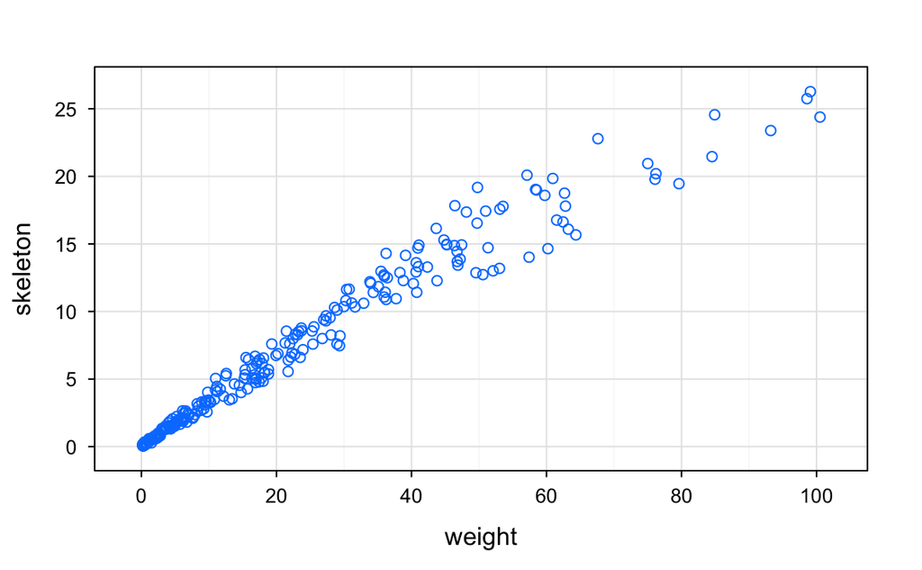

```r
chart$xyplot(data = urchin, skeleton ~ weight)
```

**Travail en cours :** prise en compte automatique des labels et du thème, similaire à celui pour `ggplot2`.

### Paramètres additionnels directement dans les formules

Exemple, couleur en fonction de l’origine.

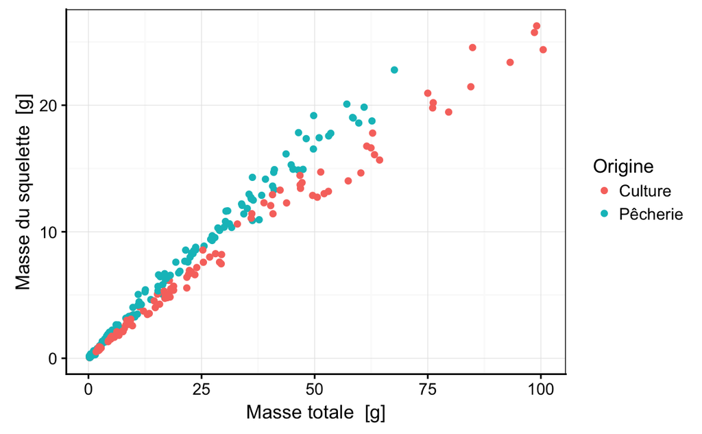

```r
chart$geom_point(data = urchin, f_aes(skeleton ~ weight, col = origin))
```

**Règle `chart` #4 :** arguments supplémentaires `aes()` directement intégrable dans la formule à l’aide de la syntaxe `%<par>=%`.

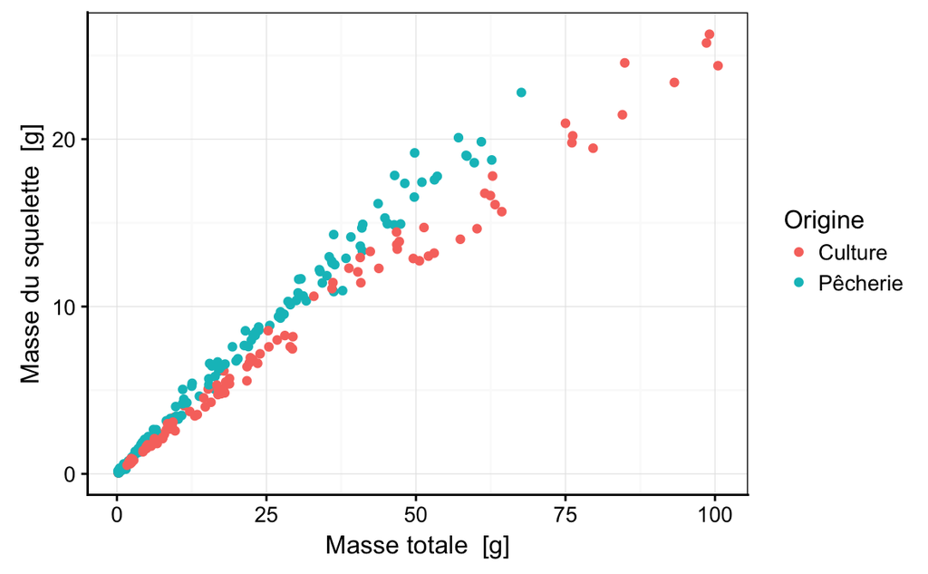

```r
chart$geom_point(data = urchin, skeleton ~ weight %col=% origin)
```

La syntaxe `|` est également reconnue pour les “facets” :

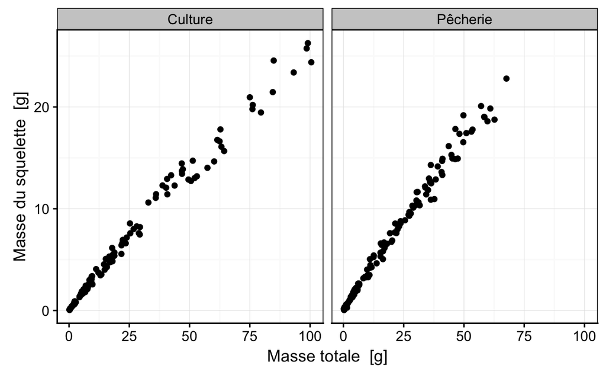

```r
chart$geom_point(data = urchin, skeleton ~ weight | origin)
```

… et toujours similaire à lattice :

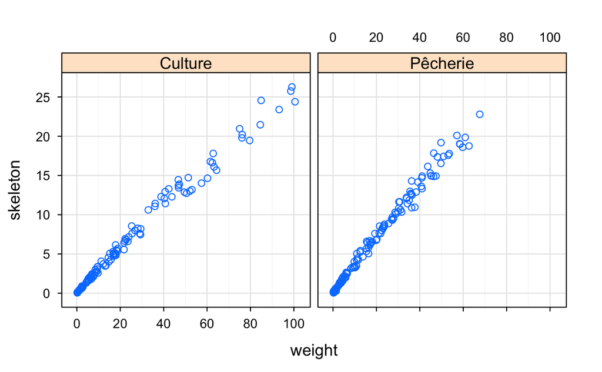

```r
chart$xyplot(data = urchin, skeleton ~ weight | origin)
```

Il est facile d’ajouter la droite de régression dans son graphique :

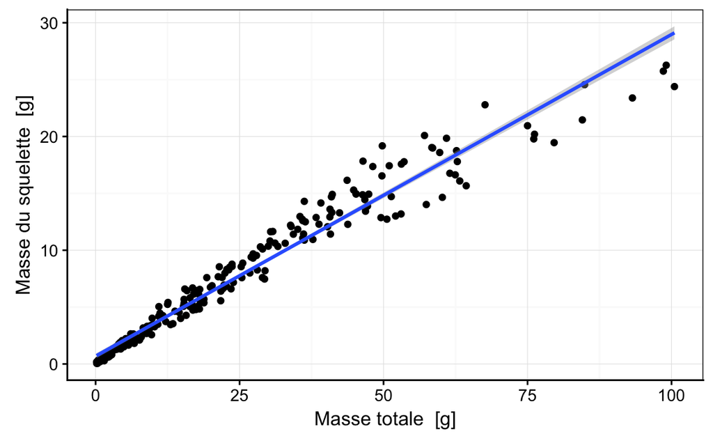

```r
chart$geom_point(data = urchin, skeleton ~ weight) +
  geom_smooth(method = "lm")
```